# Risk Factor Analysis

## Outcome Variable

**Outcome Variable:** stunted

## Predictor Variables

**Intervention Variable:** enstunt

**Adjustment Set:**

- arm
- sex
- W_mage
- meducyrs
- feducyrs
- W_mhtcm
- vagbrth
- single
- brthmon
- W_parity
- impsan
- delta_W_mage
- delta_meducyrs
- delta_feducyrs
- delta_W_mhtcm
- delta_vagbrth
- delta_single
- delta_brthmon
- delta_W_parity
- delta_impsan

## Stratifying Variables

The analysis was stratified on these variable(s):

- agecat
- studyid
- country

## Data Summary

| agecat | studyid | country | enstunt | stunted | n_cell | n |
| --- | --- | --- | --- | --- | --- | --- |
| Birth | ki0047075b-MAL-ED | BANGLADESH | 0 | 0 | 210 | 257 |
| Birth | ki0047075b-MAL-ED | BANGLADESH | 0 | 1 | 0 | 257 |
| Birth | ki0047075b-MAL-ED | BANGLADESH | 1 | 0 | 0 | 257 |
| Birth | ki0047075b-MAL-ED | BANGLADESH | 1 | 1 | 47 | 257 |
| 6 months | ki0047075b-MAL-ED | BANGLADESH | 0 | 0 | 174 | 233 |
| 6 months | ki0047075b-MAL-ED | BANGLADESH | 0 | 1 | 21 | 233 |
| 6 months | ki0047075b-MAL-ED | BANGLADESH | 1 | 0 | 16 | 233 |
| 6 months | ki0047075b-MAL-ED | BANGLADESH | 1 | 1 | 22 | 233 |
| 24 months | ki0047075b-MAL-ED | BANGLADESH | 0 | 0 | 105 | 206 |
| 24 months | ki0047075b-MAL-ED | BANGLADESH | 0 | 1 | 69 | 206 |
| 24 months | ki0047075b-MAL-ED | BANGLADESH | 1 | 0 | 8 | 206 |
| 24 months | ki0047075b-MAL-ED | BANGLADESH | 1 | 1 | 24 | 206 |
| Birth | ki0047075b-MAL-ED | BRAZIL | 0 | 0 | 170 | 191 |
| Birth | ki0047075b-MAL-ED | BRAZIL | 0 | 1 | 0 | 191 |
| Birth | ki0047075b-MAL-ED | BRAZIL | 1 | 0 | 0 | 191 |
| Birth | ki0047075b-MAL-ED | BRAZIL | 1 | 1 | 21 | 191 |
| 6 months | ki0047075b-MAL-ED | BRAZIL | 0 | 0 | 153 | 173 |
| 6 months | ki0047075b-MAL-ED | BRAZIL | 0 | 1 | 3 | 173 |
| 6 months | ki0047075b-MAL-ED | BRAZIL | 1 | 0 | 16 | 173 |
| 6 months | ki0047075b-MAL-ED | BRAZIL | 1 | 1 | 1 | 173 |
| 24 months | ki0047075b-MAL-ED | BRAZIL | 0 | 0 | 121 | 139 |
| 24 months | ki0047075b-MAL-ED | BRAZIL | 0 | 1 | 5 | 139 |
| 24 months | ki0047075b-MAL-ED | BRAZIL | 1 | 0 | 12 | 139 |
| 24 months | ki0047075b-MAL-ED | BRAZIL | 1 | 1 | 1 | 139 |
| Birth | ki0047075b-MAL-ED | INDIA | 0 | 0 | 173 | 206 |
| Birth | ki0047075b-MAL-ED | INDIA | 0 | 1 | 0 | 206 |
| Birth | ki0047075b-MAL-ED | INDIA | 1 | 0 | 0 | 206 |
| Birth | ki0047075b-MAL-ED | INDIA | 1 | 1 | 33 | 206 |
| 6 months | ki0047075b-MAL-ED | INDIA | 0 | 0 | 137 | 192 |
| 6 months | ki0047075b-MAL-ED | INDIA | 0 | 1 | 25 | 192 |

[output cut: 288 more lines]

The following strata were considered:

- agecat: 24 months, studyid: ki0047075b-MAL-ED, country: BANGLADESH
- agecat: 24 months, studyid: ki0047075b-MAL-ED, country: BRAZIL
- agecat: 24 months, studyid: ki0047075b-MAL-ED, country: INDIA
- agecat: 24 months, studyid: ki0047075b-MAL-ED, country: NEPAL
- agecat: 24 months, studyid: ki0047075b-MAL-ED, country: PERU
- agecat: 24 months, studyid: ki0047075b-MAL-ED, country: SOUTH AFRICA
- agecat: 24 months, studyid: ki0047075b-MAL-ED, country: TANZANIA, UNITED REPUBLIC OF
- agecat: 24 months, studyid: ki1000108-CMC-V-BCS-2002, country: INDIA
- agecat: 24 months, studyid: ki1000108-IRC, country: INDIA
- agecat: 24 months, studyid: ki1017093-NIH-Birth, country: BANGLADESH
- agecat: 24 months, studyid: ki1017093c-NIH-Crypto, country: BANGLADESH
- agecat: 24 months, studyid: ki1101329-Keneba, country: GAMBIA
- agecat: 24 months, studyid: ki1113344-GMS-Nepal, country: NEPAL
- agecat: 24 months, studyid: ki1114097-CMIN, country: GUINEA-BISSAU
- agecat: 24 months, studyid: ki1114097-CMIN, country: PERU
- agecat: 24 months, studyid: ki1114097-CONTENT, country: PERU
- agecat: 24 months, studyid: ki1119695-PROBIT, country: BELARUS
- agecat: 24 months, studyid: ki1126311-ZVITAMBO, country: ZIMBABWE
- agecat: 24 months, studyid: ki1135781-COHORTS, country: GUATEMALA
- agecat: 24 months, studyid: ki1135781-COHORTS, country: INDIA
- agecat: 24 months, studyid: ki1135781-COHORTS, country: PHILIPPINES
- agecat: 24 months, studyid: ki1148112-LCNI-5, country: MALAWI
- agecat: 24 months, studyid: kiGH5241-JiVitA-3, country: BANGLADESH
- agecat: 24 months, studyid: kiGH5241-JiVitA-4, country: BANGLADESH
- agecat: 6 months, studyid: ki0047075b-MAL-ED, country: BANGLADESH
- agecat: 6 months, studyid: ki0047075b-MAL-ED, country: BRAZIL
- agecat: 6 months, studyid: ki0047075b-MAL-ED, country: INDIA
- agecat: 6 months, studyid: ki0047075b-MAL-ED, country: NEPAL
- agecat: 6 months, studyid: ki0047075b-MAL-ED, country: PERU
- agecat: 6 months, studyid: ki0047075b-MAL-ED, country: SOUTH AFRICA
- agecat: 6 months, studyid: ki0047075b-MAL-ED, country: TANZANIA, UNITED REPUBLIC OF
- agecat: 6 months, studyid: ki1000108-CMC-V-BCS-2002, country: INDIA
- agecat: 6 months, studyid: ki1000108-IRC, country: INDIA
- agecat: 6 months, studyid: ki1000109-EE, country: PAKISTAN
- agecat: 6 months, studyid: ki1000109-ResPak, country: PAKISTAN
- agecat: 6 months, studyid: ki1000304b-SAS-CompFeed, country: INDIA
- agecat: 6 months, studyid: ki1000304b-SAS-FoodSuppl, country: INDIA
- agecat: 6 months, studyid: ki1017093-NIH-Birth, country: BANGLADESH
- agecat: 6 months, studyid: ki1017093c-NIH-Crypto, country: BANGLADESH
- agecat: 6 months, studyid: ki1066203-TanzaniaChild2, country: TANZANIA, UNITED REPUBLIC OF
- agecat: 6 months, studyid: ki1101329-Keneba, country: GAMBIA
- agecat: 6 months, studyid: ki1112895-Guatemala BSC, country: GUATEMALA
- agecat: 6 months, studyid: ki1113344-GMS-Nepal, country: NEPAL
- agecat: 6 months, studyid: ki1114097-CMIN, country: BRAZIL
- agecat: 6 months, studyid: ki1114097-CMIN, country: GUINEA-BISSAU
- agecat: 6 months, studyid: ki1114097-CMIN, country: PERU
- agecat: 6 months, studyid: ki1114097-CONTENT, country: PERU
- agecat: 6 months, studyid: ki1119695-PROBIT, country: BELARUS
- agecat: 6 months, studyid: ki1126311-ZVITAMBO, country: ZIMBABWE
- agecat: 6 months, studyid: ki1135781-COHORTS, country: GUATEMALA
- agecat: 6 months, studyid: ki1135781-COHORTS, country: INDIA
- agecat: 6 months, studyid: ki1135781-COHORTS, country: PHILIPPINES
- agecat: 6 months, studyid: ki1148112-LCNI-5, country: MALAWI
- agecat: 6 months, studyid: kiGH5241-JiVitA-3, country: BANGLADESH
- agecat: 6 months, studyid: kiGH5241-JiVitA-4, country: BANGLADESH
- agecat: Birth, studyid: ki0047075b-MAL-ED, country: BANGLADESH
- agecat: Birth, studyid: ki0047075b-MAL-ED, country: BRAZIL
- agecat: Birth, studyid: ki0047075b-MAL-ED, country: INDIA
- agecat: Birth, studyid: ki0047075b-MAL-ED, country: NEPAL
- agecat: Birth, studyid: ki0047075b-MAL-ED, country: PERU
- agecat: Birth, studyid: ki0047075b-MAL-ED, country: SOUTH AFRICA
- agecat: Birth, studyid: ki0047075b-MAL-ED, country: TANZANIA, UNITED REPUBLIC OF
- agecat: Birth, studyid: ki1000108-CMC-V-BCS-2002, country: INDIA
- agecat: Birth, studyid: ki1000108-IRC, country: INDIA
- agecat: Birth, studyid: ki1000109-EE, country: PAKISTAN
- agecat: Birth, studyid: ki1000109-ResPak, country: PAKISTAN
- agecat: Birth, studyid: ki1000304b-SAS-CompFeed, country: INDIA
- agecat: Birth, studyid: ki1017093-NIH-Birth, country: BANGLADESH
- agecat: Birth, studyid: ki1017093c-NIH-Crypto, country: BANGLADESH
- agecat: Birth, studyid: ki1101329-Keneba, country: GAMBIA
- agecat: Birth, studyid: ki1114097-CMIN, country: BANGLADESH
- agecat: Birth, studyid: ki1114097-CMIN, country: BRAZIL
- agecat: Birth, studyid: ki1114097-CMIN, country: PERU
- agecat: Birth, studyid: ki1114097-CONTENT, country: PERU
- agecat: Birth, studyid: ki1119695-PROBIT, country: BELARUS
- agecat: Birth, studyid: ki1126311-ZVITAMBO, country: ZIMBABWE
- agecat: Birth, studyid: ki1135781-COHORTS, country: GUATEMALA
- agecat: Birth, studyid: ki1135781-COHORTS, country: INDIA
- agecat: Birth, studyid: ki1135781-COHORTS, country: PHILIPPINES
- agecat: Birth, studyid: kiGH5241-JiVitA-3, country: BANGLADESH
- agecat: Birth, studyid: kiGH5241-JiVitA-4, country: BANGLADESH

### Dropped Strata

Some strata were dropped due to rare outcomes:

- agecat: Birth, studyid: ki0047075b-MAL-ED, country: BANGLADESH
- agecat: Birth, studyid: ki0047075b-MAL-ED, country: BRAZIL
- agecat: 6 months, studyid: ki0047075b-MAL-ED, country: BRAZIL
- agecat: 24 months, studyid: ki0047075b-MAL-ED, country: BRAZIL
- agecat: Birth, studyid: ki0047075b-MAL-ED, country: INDIA
- agecat: Birth, studyid: ki0047075b-MAL-ED, country: NEPAL
- agecat: 6 months, studyid: ki0047075b-MAL-ED, country: NEPAL
- agecat: Birth, studyid: ki0047075b-MAL-ED, country: PERU
- agecat: Birth, studyid: ki0047075b-MAL-ED, country: SOUTH AFRICA
- agecat: Birth, studyid: ki0047075b-MAL-ED, country: TANZANIA, UNITED REPUBLIC OF
- agecat: 6 months, studyid: ki0047075b-MAL-ED, country: TANZANIA, UNITED REPUBLIC OF
- agecat: 24 months, studyid: ki0047075b-MAL-ED, country: TANZANIA, UNITED REPUBLIC OF
- agecat: Birth, studyid: ki1000108-CMC-V-BCS-2002, country: INDIA
- agecat: Birth, studyid: ki1000108-IRC, country: INDIA
- agecat: 6 months, studyid: ki1000109-EE, country: PAKISTAN
- agecat: Birth, studyid: ki1000109-EE, country: PAKISTAN
- agecat: Birth, studyid: ki1000109-ResPak, country: PAKISTAN
- agecat: Birth, studyid: ki1000304b-SAS-CompFeed, country: INDIA
- agecat: Birth, studyid: ki1017093-NIH-Birth, country: BANGLADESH
- agecat: Birth, studyid: ki1017093c-NIH-Crypto, country: BANGLADESH
- agecat: 6 months, studyid: ki1017093c-NIH-Crypto, country: BANGLADESH
- agecat: 24 months, studyid: ki1017093c-NIH-Crypto, country: BANGLADESH
- agecat: 6 months, studyid: ki1066203-TanzaniaChild2, country: TANZANIA, UNITED REPUBLIC OF
- agecat: Birth, studyid: ki1101329-Keneba, country: GAMBIA
- agecat: 6 months, studyid: ki1113344-GMS-Nepal, country: NEPAL
- agecat: 24 months, studyid: ki1113344-GMS-Nepal, country: NEPAL
- agecat: Birth, studyid: ki1114097-CMIN, country: BANGLADESH
- agecat: Birth, studyid: ki1114097-CMIN, country: BRAZIL
- agecat: 6 months, studyid: ki1114097-CMIN, country: BRAZIL
- agecat: 24 months, studyid: ki1114097-CMIN, country: GUINEA-BISSAU
- agecat: 6 months, studyid: ki1114097-CMIN, country: PERU
- agecat: 24 months, studyid: ki1114097-CMIN, country: PERU
- agecat: 6 months, studyid: ki1114097-CONTENT, country: PERU
- agecat: 24 months, studyid: ki1114097-CONTENT, country: PERU
- agecat: Birth, studyid: ki1114097-CONTENT, country: PERU
- agecat: Birth, studyid: ki1119695-PROBIT, country: BELARUS
- agecat: 24 months, studyid: ki1119695-PROBIT, country: BELARUS
- agecat: Birth, studyid: ki1126311-ZVITAMBO, country: ZIMBABWE
- agecat: Birth, studyid: ki1135781-COHORTS, country: GUATEMALA
- agecat: Birth, studyid: ki1135781-COHORTS, country: INDIA
- agecat: Birth, studyid: ki1135781-COHORTS, country: PHILIPPINES
- agecat: 6 months, studyid: ki1148112-LCNI-5, country: MALAWI
- agecat: Birth, studyid: kiGH5241-JiVitA-3, country: BANGLADESH
- agecat: Birth, studyid: kiGH5241-JiVitA-4, country: BANGLADESH

## Methods Detail

We’re interested in the causal parameters $E[Y_a]$ for all values of $a \in \mathcal{A}$. These parameters represent the mean outcome if, possibly contrary to fact, we intervened to set all units to have $A=a$. Under the randomization and positivity assumptions, these are identified by the statistical parameters $\psi_a=E_W[E_{Y|A,W}(Y|A=a,W)]$. In addition, we’re interested in the mean of $Y$, $E[Y]$ under no intervention (the observed mean). We will estimate these parameters by using SuperLearner to fit the relevant likelihood factors – $E_{Y|A,W}(Y|A=a,W)$ and $p(A=a|W)$, and then updating our likelihood fit using a joint TMLE.

For unadjusted analyses ($W=\{\}$), initial likelihoods were estimated using Lrnr_glm to estimate the simple $E(Y|A)$ and Lrnr_mean to estimate $p(A)$. For adjusted analyses, a small library containing Lrnr_glmnet, Lrnr_xgboost, and Lrnr_mean was used.

Having estimated these parameters, we will then use the delta method to estimate relative risks and attributable risks relative to a prespecified baseline level of $A$.

[output not shown]

# Results Detail

## Results Plots

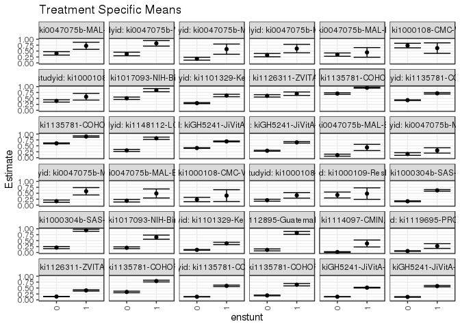

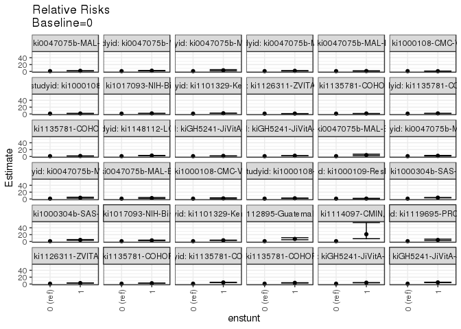

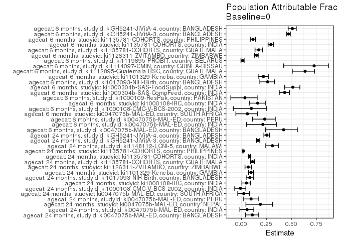

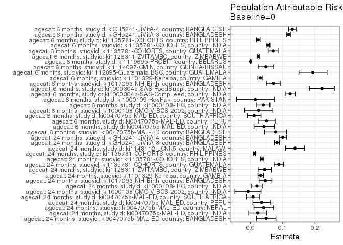

## Results Table

### Parameter: TSM

| agecat | studyid | country | intervention_level | baseline_level | estimate | ci_lower | ci_upper |
| --- | --- | --- | --- | --- | --- | --- | --- |
| 6 months | ki0047075b-MAL-ED | BANGLADESH | 0 | NA | 0.1064209 | 0.0634082 | 0.1494337 |
| 6 months | ki0047075b-MAL-ED | BANGLADESH | 1 | NA | 0.4317167 | 0.3002186 | 0.5632147 |
| 6 months | ki0047075b-MAL-ED | INDIA | 0 | NA | 0.1554328 | 0.1005650 | 0.2103005 |
| 6 months | ki0047075b-MAL-ED | INDIA | 1 | NA | 0.3064740 | 0.1944194 | 0.4185285 |
| 6 months | ki0047075b-MAL-ED | PERU | 0 | NA | 0.1650790 | 0.1173313 | 0.2128268 |
| 6 months | ki0047075b-MAL-ED | PERU | 1 | NA | 0.5827193 | 0.4272263 | 0.7382123 |
| 6 months | ki0047075b-MAL-ED | SOUTH AFRICA | 0 | NA | 0.1845445 | 0.1302728 | 0.2388163 |
| 6 months | ki0047075b-MAL-ED | SOUTH AFRICA | 1 | NA | 0.4900968 | 0.2999944 | 0.6801992 |
| 6 months | ki1000108-CMC-V-BCS-2002 | INDIA | 0 | NA | 0.2345679 | 0.1418066 | 0.3273292 |
| 6 months | ki1000108-CMC-V-BCS-2002 | INDIA | 1 | NA | 0.4000000 | 0.1507806 | 0.6492194 |
| 6 months | ki1000108-IRC | INDIA | 0 | NA | 0.2056081 | 0.1638847 | 0.2473314 |
| 6 months | ki1000108-IRC | INDIA | 1 | NA | 0.4111261 | 0.2932349 | 0.5290174 |
| 6 months | ki1000109-ResPak | PAKISTAN | 0 | NA | 0.4261856 | 0.3012500 | 0.5511212 |
| 6 months | ki1000109-ResPak | PAKISTAN | 1 | NA | 0.4849848 | 0.2429138 | 0.7270558 |
| 6 months | ki1000304b-SAS-CompFeed | INDIA | 0 | NA | 0.1607960 | 0.1418925 | 0.1796996 |
| 6 months | ki1000304b-SAS-CompFeed | INDIA | 1 | NA | 0.6210365 | 0.5882404 | 0.6538327 |
| 6 months | ki1000304b-SAS-FoodSuppl | INDIA | 0 | NA | 0.2071153 | 0.1634592 | 0.2507714 |
| 6 months | ki1000304b-SAS-FoodSuppl | INDIA | 1 | NA | 0.9373435 | 0.8930660 | 0.9816210 |
| 6 months | ki1017093-NIH-Birth | BANGLADESH | 0 | NA | 0.1992458 | 0.1630179 | 0.2354737 |
| 6 months | ki1017093-NIH-Birth | BANGLADESH | 1 | NA | 0.6460269 | 0.5577642 | 0.7342895 |
| 6 months | ki1101329-Keneba | GAMBIA | 0 | NA | 0.1101144 | 0.0961093 | 0.1241195 |
| 6 months | ki1101329-Keneba | GAMBIA | 1 | NA | 0.3828433 | 0.3331457 | 0.4325409 |
| 6 months | ki1112895-Guatemala BSC | GUATEMALA | 0 | NA | 0.1094354 | 0.0686676 | 0.1502031 |
| 6 months | ki1112895-Guatemala BSC | GUATEMALA | 1 | NA | 0.8272274 | 0.7636457 | 0.8908091 |
| 6 months | ki1114097-CMIN | GUINEA-BISSAU | 0 | NA | 0.0178402 | 0.0023072 | 0.0333731 |
| 6 months | ki1114097-CMIN | GUINEA-BISSAU | 1 | NA | 0.3789610 | 0.2318279 | 0.5260940 |
| 6 months | ki1119695-PROBIT | BELARUS | 0 | NA | 0.0600915 | 0.0470528 | 0.0731303 |
| 6 months | ki1119695-PROBIT | BELARUS | 1 | NA | 0.2719157 | 0.1713615 | 0.3724698 |
| 6 months | ki1126311-ZVITAMBO | ZIMBABWE | 0 | NA | 0.1403080 | 0.1324165 | 0.1481995 |
| 6 months | ki1126311-ZVITAMBO | ZIMBABWE | 1 | NA | 0.3998387 | 0.3722836 | 0.4273938 |
| 6 months | ki1135781-COHORTS | GUATEMALA | 0 | NA | 0.3343313 | 0.3009217 | 0.3677409 |
| 6 months | ki1135781-COHORTS | GUATEMALA | 1 | NA | 0.7939639 | 0.7587377 | 0.8291902 |
| 6 months | ki1135781-COHORTS | INDIA | 0 | NA | 0.1316869 | 0.1231148 | 0.1402591 |
| 6 months | ki1135781-COHORTS | INDIA | 1 | NA | 0.5915713 | 0.5604211 | 0.6227216 |
| 6 months | ki1135781-COHORTS | PHILIPPINES | 0 | NA | 0.1871641 | 0.1720950 | 0.2022332 |
| 6 months | ki1135781-COHORTS | PHILIPPINES | 1 | NA | 0.6408117 | 0.5892111 | 0.6924122 |
| 6 months | kiGH5241-JiVitA-3 | BANGLADESH | 0 | NA | 0.1325589 | 0.1253287 | 0.1397890 |
| 6 months | kiGH5241-JiVitA-3 | BANGLADESH | 1 | NA | 0.5159926 | 0.5012527 | 0.5307325 |
| 6 months | kiGH5241-JiVitA-4 | BANGLADESH | 0 | NA | 0.1240550 | 0.1105675 | 0.1375426 |
| 6 months | kiGH5241-JiVitA-4 | BANGLADESH | 1 | NA | 0.5809148 | 0.5508604 | 0.6109691 |
| 24 months | ki0047075b-MAL-ED | BANGLADESH | 0 | NA | 0.4023313 | 0.3301789 | 0.4744836 |
| 24 months | ki0047075b-MAL-ED | BANGLADESH | 1 | NA | 0.7207993 | 0.5711075 | 0.8704911 |
| 24 months | ki0047075b-MAL-ED | INDIA | 0 | NA | 0.3762601 | 0.3014002 | 0.4511201 |
| 24 months | ki0047075b-MAL-ED | INDIA | 1 | NA | 0.8249956 | 0.7089279 | 0.9410633 |
| 24 months | ki0047075b-MAL-ED | NEPAL | 0 | NA | 0.1768086 | 0.1155002 | 0.2381169 |
| 24 months | ki0047075b-MAL-ED | NEPAL | 1 | NA | 0.5802802 | 0.3647099 | 0.7958506 |
| 24 months | ki0047075b-MAL-ED | PERU | 0 | NA | 0.3280718 | 0.2572882 | 0.3988554 |
| 24 months | ki0047075b-MAL-ED | PERU | 1 | NA | 0.6040240 | 0.4256961 | 0.7823519 |
| 24 months | ki0047075b-MAL-ED | SOUTH AFRICA | 0 | NA | 0.3499533 | 0.2805551 | 0.4193515 |
| 24 months | ki0047075b-MAL-ED | SOUTH AFRICA | 1 | NA | 0.4429583 | 0.2400570 | 0.6458596 |
| 24 months | ki1000108-CMC-V-BCS-2002 | INDIA | 0 | NA | 0.7316368 | 0.6354702 | 0.8278035 |
| 24 months | ki1000108-CMC-V-BCS-2002 | INDIA | 1 | NA | 0.6241709 | 0.4032382 | 0.8451036 |
| 24 months | ki1000108-IRC | INDIA | 0 | NA | 0.3951825 | 0.3447622 | 0.4456028 |
| 24 months | ki1000108-IRC | INDIA | 1 | NA | 0.5732449 | 0.4319034 | 0.7145865 |
| 24 months | ki1017093-NIH-Birth | BANGLADESH | 0 | NA | 0.5073856 | 0.4564279 | 0.5583433 |
| 24 months | ki1017093-NIH-Birth | BANGLADESH | 1 | NA | 0.8495965 | 0.7818904 | 0.9173026 |
| 24 months | ki1101329-Keneba | GAMBIA | 0 | NA | 0.3023044 | 0.2796108 | 0.3249980 |
| 24 months | ki1101329-Keneba | GAMBIA | 1 | NA | 0.6236328 | 0.5714972 | 0.6757684 |
| 24 months | ki1126311-ZVITAMBO | ZIMBABWE | 0 | NA | 0.6087230 | 0.5583200 | 0.6591261 |
| 24 months | ki1126311-ZVITAMBO | ZIMBABWE | 1 | NA | 0.7005560 | 0.6275211 | 0.7735908 |
| 24 months | ki1135781-COHORTS | GUATEMALA | 0 | NA | 0.7063994 | 0.6736161 | 0.7391828 |
| 24 months | ki1135781-COHORTS | GUATEMALA | 1 | NA | 0.9535854 | 0.9341251 | 0.9730458 |
| 24 months | ki1135781-COHORTS | INDIA | 0 | NA | 0.4275263 | 0.4133585 | 0.4416940 |
| 24 months | ki1135781-COHORTS | INDIA | 1 | NA | 0.7161996 | 0.6864100 | 0.7459892 |
| 24 months | ki1135781-COHORTS | PHILIPPINES | 0 | NA | 0.6053611 | 0.5855392 | 0.6251829 |
| 24 months | ki1135781-COHORTS | PHILIPPINES | 1 | NA | 0.8942191 | 0.8655942 | 0.9228440 |
| 24 months | ki1148112-LCNI-5 | MALAWI | 0 | NA | 0.3060785 | 0.2630492 | 0.3491078 |
| 24 months | ki1148112-LCNI-5 | MALAWI | 1 | NA | 0.8184181 | 0.7685386 | 0.8682976 |
| 24 months | kiGH5241-JiVitA-3 | BANGLADESH | 0 | NA | 0.4074961 | 0.3923816 | 0.4226106 |
| 24 months | kiGH5241-JiVitA-3 | BANGLADESH | 1 | NA | 0.6866432 | 0.6680293 | 0.7052571 |
| 24 months | kiGH5241-JiVitA-4 | BANGLADESH | 0 | NA | 0.2935734 | 0.2744441 | 0.3127028 |
| 24 months | kiGH5241-JiVitA-4 | BANGLADESH | 1 | NA | 0.6454624 | 0.6149200 | 0.6760048 |

### Parameter: E(Y)

| agecat | studyid | country | intervention_level | baseline_level | estimate | ci_lower | ci_upper |
| --- | --- | --- | --- | --- | --- | --- | --- |
| 6 months | ki0047075b-MAL-ED | BANGLADESH | NA | NA | 0.1845494 | 0.1346311 | 0.2344676 |
| 6 months | ki0047075b-MAL-ED | INDIA | NA | NA | 0.1979167 | 0.1414123 | 0.2544211 |
| 6 months | ki0047075b-MAL-ED | PERU | NA | NA | 0.2153846 | 0.1653196 | 0.2654496 |
| 6 months | ki0047075b-MAL-ED | SOUTH AFRICA | NA | NA | 0.1962617 | 0.1429241 | 0.2495993 |
| 6 months | ki1000108-CMC-V-BCS-2002 | INDIA | NA | NA | 0.2604167 | 0.1721668 | 0.3486666 |
| 6 months | ki1000108-IRC | INDIA | NA | NA | 0.2457002 | 0.2038248 | 0.2875757 |
| 6 months | ki1000109-ResPak | PAKISTAN | NA | NA | 0.4415584 | 0.3299173 | 0.5531996 |
| 6 months | ki1000304b-SAS-CompFeed | INDIA | NA | NA | 0.2837838 | 0.2660825 | 0.3014850 |
| 6 months | ki1000304b-SAS-FoodSuppl | INDIA | NA | NA | 0.4277929 | 0.3771054 | 0.4784804 |
| 6 months | ki1017093-NIH-Birth | BANGLADESH | NA | NA | 0.2701689 | 0.2324359 | 0.3079018 |
| 6 months | ki1101329-Keneba | GAMBIA | NA | NA | 0.1412835 | 0.1263398 | 0.1562272 |
| 6 months | ki1112895-Guatemala BSC | GUATEMALA | NA | NA | 0.3027211 | 0.2501147 | 0.3553275 |
| 6 months | ki1114097-CMIN | GUINEA-BISSAU | NA | NA | 0.0658307 | 0.0385748 | 0.0930867 |
| 6 months | ki1119695-PROBIT | BELARUS | NA | NA | 0.0607877 | 0.0476810 | 0.0738944 |
| 6 months | ki1126311-ZVITAMBO | ZIMBABWE | NA | NA | 0.1655282 | 0.1574825 | 0.1735739 |
| 6 months | ki1135781-COHORTS | GUATEMALA | NA | NA | 0.4047904 | 0.3714773 | 0.4381035 |
| 6 months | ki1135781-COHORTS | INDIA | NA | NA | 0.1866270 | 0.1773180 | 0.1959361 |
| 6 months | ki1135781-COHORTS | PHILIPPINES | NA | NA | 0.2116950 | 0.1962891 | 0.2271010 |
| 6 months | kiGH5241-JiVitA-3 | BANGLADESH | NA | NA | 0.2507560 | 0.2426260 | 0.2588861 |
| 6 months | kiGH5241-JiVitA-4 | BANGLADESH | NA | NA | 0.2535395 | 0.2390830 | 0.2679961 |
| 24 months | ki0047075b-MAL-ED | BANGLADESH | NA | NA | 0.4514563 | 0.3833347 | 0.5195779 |
| 24 months | ki0047075b-MAL-ED | INDIA | NA | NA | 0.3989071 | 0.3277662 | 0.4700480 |
| 24 months | ki0047075b-MAL-ED | NEPAL | NA | NA | 0.2181818 | 0.1549714 | 0.2813922 |
| 24 months | ki0047075b-MAL-ED | PERU | NA | NA | 0.3631579 | 0.2945963 | 0.4317195 |
| 24 months | ki0047075b-MAL-ED | SOUTH AFRICA | NA | NA | 0.3582090 | 0.2917585 | 0.4246594 |
| 24 months | ki1000108-CMC-V-BCS-2002 | INDIA | NA | NA | 0.7244898 | 0.6355805 | 0.8133991 |
| 24 months | ki1000108-IRC | INDIA | NA | NA | 0.4156479 | 0.3678270 | 0.4634689 |
| 24 months | ki1017093-NIH-Birth | BANGLADESH | NA | NA | 0.5539906 | 0.5067324 | 0.6012488 |
| 24 months | ki1101329-Keneba | GAMBIA | NA | NA | 0.3346868 | 0.3124056 | 0.3569679 |
| 24 months | ki1126311-ZVITAMBO | ZIMBABWE | NA | NA | 0.6532438 | 0.6090735 | 0.6974142 |
| 24 months | ki1135781-COHORTS | GUATEMALA | NA | NA | 0.7943337 | 0.7686586 | 0.8200088 |
| 24 months | ki1135781-COHORTS | INDIA | NA | NA | 0.4645790 | 0.4510699 | 0.4780880 |
| 24 months | ki1135781-COHORTS | PHILIPPINES | NA | NA | 0.6172738 | 0.5979960 | 0.6365517 |
| 24 months | ki1148112-LCNI-5 | MALAWI | NA | NA | 0.4438596 | 0.4030365 | 0.4846828 |
| 24 months | kiGH5241-JiVitA-3 | BANGLADESH | NA | NA | 0.4895981 | 0.4764416 | 0.5027546 |
| 24 months | kiGH5241-JiVitA-4 | BANGLADESH | NA | NA | 0.3937709 | 0.3760204 | 0.4115213 |

### Parameter: RR

| agecat | studyid | country | intervention_level | baseline_level | estimate | ci_lower | ci_upper |
| --- | --- | --- | --- | --- | --- | --- | --- |
| 6 months | ki0047075b-MAL-ED | BANGLADESH | 0 | 0 | 1.0000000 | 1.0000000 | 1.000000 |
| 6 months | ki0047075b-MAL-ED | BANGLADESH | 1 | 0 | 4.0566889 | 2.4823493 | 6.629496 |
| 6 months | ki0047075b-MAL-ED | INDIA | 0 | 0 | 1.0000000 | 1.0000000 | 1.000000 |
| 6 months | ki0047075b-MAL-ED | INDIA | 1 | 0 | 1.9717464 | 1.1963952 | 3.249582 |
| 6 months | ki0047075b-MAL-ED | PERU | 0 | 0 | 1.0000000 | 1.0000000 | 1.000000 |
| 6 months | ki0047075b-MAL-ED | PERU | 1 | 0 | 3.5299409 | 2.3949651 | 5.202782 |
| 6 months | ki0047075b-MAL-ED | SOUTH AFRICA | 0 | 0 | 1.0000000 | 1.0000000 | 1.000000 |
| 6 months | ki0047075b-MAL-ED | SOUTH AFRICA | 1 | 0 | 2.6557104 | 1.6340209 | 4.316223 |
| 6 months | ki1000108-CMC-V-BCS-2002 | INDIA | 0 | 0 | 1.0000000 | 1.0000000 | 1.000000 |
| 6 months | ki1000108-CMC-V-BCS-2002 | INDIA | 1 | 0 | 1.7052632 | 0.8152716 | 3.566814 |
| 6 months | ki1000108-IRC | INDIA | 0 | 0 | 1.0000000 | 1.0000000 | 1.000000 |
| 6 months | ki1000108-IRC | INDIA | 1 | 0 | 1.9995624 | 1.4098305 | 2.835979 |
| 6 months | ki1000109-ResPak | PAKISTAN | 0 | 0 | 1.0000000 | 1.0000000 | 1.000000 |
| 6 months | ki1000109-ResPak | PAKISTAN | 1 | 0 | 1.1379663 | 0.6379343 | 2.029938 |
| 6 months | ki1000304b-SAS-CompFeed | INDIA | 0 | 0 | 1.0000000 | 1.0000000 | 1.000000 |
| 6 months | ki1000304b-SAS-CompFeed | INDIA | 1 | 0 | 3.8622624 | 3.4430663 | 4.332496 |
| 6 months | ki1000304b-SAS-FoodSuppl | INDIA | 0 | 0 | 1.0000000 | 1.0000000 | 1.000000 |
| 6 months | ki1000304b-SAS-FoodSuppl | INDIA | 1 | 0 | 4.5257091 | 3.6454885 | 5.618463 |
| 6 months | ki1017093-NIH-Birth | BANGLADESH | 0 | 0 | 1.0000000 | 1.0000000 | 1.000000 |
| 6 months | ki1017093-NIH-Birth | BANGLADESH | 1 | 0 | 3.2423611 | 2.5948667 | 4.051424 |
| 6 months | ki1101329-Keneba | GAMBIA | 0 | 0 | 1.0000000 | 1.0000000 | 1.000000 |
| 6 months | ki1101329-Keneba | GAMBIA | 1 | 0 | 3.4767772 | 2.9043433 | 4.162035 |
| 6 months | ki1112895-Guatemala BSC | GUATEMALA | 0 | 0 | 1.0000000 | 1.0000000 | 1.000000 |
| 6 months | ki1112895-Guatemala BSC | GUATEMALA | 1 | 0 | 7.5590504 | 5.1793864 | 11.032049 |
| 6 months | ki1114097-CMIN | GUINEA-BISSAU | 0 | 0 | 1.0000000 | 1.0000000 | 1.000000 |
| 6 months | ki1114097-CMIN | GUINEA-BISSAU | 1 | 0 | 21.2420255 | 8.1821691 | 55.147192 |
| 6 months | ki1119695-PROBIT | BELARUS | 0 | 0 | 1.0000000 | 1.0000000 | 1.000000 |
| 6 months | ki1119695-PROBIT | BELARUS | 1 | 0 | 4.5250246 | 2.9730356 | 6.887185 |
| 6 months | ki1126311-ZVITAMBO | ZIMBABWE | 0 | 0 | 1.0000000 | 1.0000000 | 1.000000 |
| 6 months | ki1126311-ZVITAMBO | ZIMBABWE | 1 | 0 | 2.8497207 | 2.6083319 | 3.113449 |
| 6 months | ki1135781-COHORTS | GUATEMALA | 0 | 0 | 1.0000000 | 1.0000000 | 1.000000 |
| 6 months | ki1135781-COHORTS | GUATEMALA | 1 | 0 | 2.3747820 | 2.1340997 | 2.642608 |
| 6 months | ki1135781-COHORTS | INDIA | 0 | 0 | 1.0000000 | 1.0000000 | 1.000000 |
| 6 months | ki1135781-COHORTS | INDIA | 1 | 0 | 4.4922549 | 4.1327910 | 4.882985 |
| 6 months | ki1135781-COHORTS | PHILIPPINES | 0 | 0 | 1.0000000 | 1.0000000 | 1.000000 |
| 6 months | ki1135781-COHORTS | PHILIPPINES | 1 | 0 | 3.4237953 | 3.0578727 | 3.833506 |
| 6 months | kiGH5241-JiVitA-3 | BANGLADESH | 0 | 0 | 1.0000000 | 1.0000000 | 1.000000 |
| 6 months | kiGH5241-JiVitA-3 | BANGLADESH | 1 | 0 | 3.8925533 | 3.6759337 | 4.121938 |
| 6 months | kiGH5241-JiVitA-4 | BANGLADESH | 0 | 0 | 1.0000000 | 1.0000000 | 1.000000 |
| 6 months | kiGH5241-JiVitA-4 | BANGLADESH | 1 | 0 | 4.6827181 | 4.1377832 | 5.299419 |
| 24 months | ki0047075b-MAL-ED | BANGLADESH | 0 | 0 | 1.0000000 | 1.0000000 | 1.000000 |
| 24 months | ki0047075b-MAL-ED | BANGLADESH | 1 | 0 | 1.7915568 | 1.3677576 | 2.346670 |
| 24 months | ki0047075b-MAL-ED | INDIA | 0 | 0 | 1.0000000 | 1.0000000 | 1.000000 |
| 24 months | ki0047075b-MAL-ED | INDIA | 1 | 0 | 2.1926202 | 1.7238895 | 2.788800 |
| 24 months | ki0047075b-MAL-ED | NEPAL | 0 | 0 | 1.0000000 | 1.0000000 | 1.000000 |
| 24 months | ki0047075b-MAL-ED | NEPAL | 1 | 0 | 3.2819688 | 1.9889081 | 5.415695 |
| 24 months | ki0047075b-MAL-ED | PERU | 0 | 0 | 1.0000000 | 1.0000000 | 1.000000 |
| 24 months | ki0047075b-MAL-ED | PERU | 1 | 0 | 1.8411335 | 1.2869944 | 2.633868 |
| 24 months | ki0047075b-MAL-ED | SOUTH AFRICA | 0 | 0 | 1.0000000 | 1.0000000 | 1.000000 |
| 24 months | ki0047075b-MAL-ED | SOUTH AFRICA | 1 | 0 | 1.2657639 | 0.7722082 | 2.074775 |
| 24 months | ki1000108-CMC-V-BCS-2002 | INDIA | 0 | 0 | 1.0000000 | 1.0000000 | 1.000000 |
| 24 months | ki1000108-CMC-V-BCS-2002 | INDIA | 1 | 0 | 0.8531157 | 0.5850211 | 1.244069 |
| 24 months | ki1000108-IRC | INDIA | 0 | 0 | 1.0000000 | 1.0000000 | 1.000000 |
| 24 months | ki1000108-IRC | INDIA | 1 | 0 | 1.4505827 | 1.0989986 | 1.914643 |
| 24 months | ki1017093-NIH-Birth | BANGLADESH | 0 | 0 | 1.0000000 | 1.0000000 | 1.000000 |
| 24 months | ki1017093-NIH-Birth | BANGLADESH | 1 | 0 | 1.6744593 | 1.4750632 | 1.900809 |
| 24 months | ki1101329-Keneba | GAMBIA | 0 | 0 | 1.0000000 | 1.0000000 | 1.000000 |
| 24 months | ki1101329-Keneba | GAMBIA | 1 | 0 | 2.0629296 | 1.8464556 | 2.304782 |
| 24 months | ki1126311-ZVITAMBO | ZIMBABWE | 0 | 0 | 1.0000000 | 1.0000000 | 1.000000 |
| 24 months | ki1126311-ZVITAMBO | ZIMBABWE | 1 | 0 | 1.1508616 | 1.0118064 | 1.309028 |
| 24 months | ki1135781-COHORTS | GUATEMALA | 0 | 0 | 1.0000000 | 1.0000000 | 1.000000 |
| 24 months | ki1135781-COHORTS | GUATEMALA | 1 | 0 | 1.3499238 | 1.2838402 | 1.419409 |
| 24 months | ki1135781-COHORTS | INDIA | 0 | 0 | 1.0000000 | 1.0000000 | 1.000000 |
| 24 months | ki1135781-COHORTS | INDIA | 1 | 0 | 1.6752177 | 1.5898586 | 1.765160 |
| 24 months | ki1135781-COHORTS | PHILIPPINES | 0 | 0 | 1.0000000 | 1.0000000 | 1.000000 |
| 24 months | ki1135781-COHORTS | PHILIPPINES | 1 | 0 | 1.4771664 | 1.4122722 | 1.545043 |
| 24 months | ki1148112-LCNI-5 | MALAWI | 0 | 0 | 1.0000000 | 1.0000000 | 1.000000 |
| 24 months | ki1148112-LCNI-5 | MALAWI | 1 | 0 | 2.6738832 | 2.2962204 | 3.113661 |
| 24 months | kiGH5241-JiVitA-3 | BANGLADESH | 0 | 0 | 1.0000000 | 1.0000000 | 1.000000 |
| 24 months | kiGH5241-JiVitA-3 | BANGLADESH | 1 | 0 | 1.6850302 | 1.6131128 | 1.760154 |
| 24 months | kiGH5241-JiVitA-4 | BANGLADESH | 0 | 0 | 1.0000000 | 1.0000000 | 1.000000 |
| 24 months | kiGH5241-JiVitA-4 | BANGLADESH | 1 | 0 | 2.1986402 | 2.0320620 | 2.378874 |

### Parameter: PAR

| agecat | studyid | country | intervention_level | baseline_level | estimate | ci_lower | ci_upper |
| --- | --- | --- | --- | --- | --- | --- | --- |
| 6 months | ki0047075b-MAL-ED | BANGLADESH | 0 | NA | 0.0781284 | 0.0441704 | 0.1120865 |
| 6 months | ki0047075b-MAL-ED | INDIA | 0 | NA | 0.0424839 | 0.0112268 | 0.0737411 |
| 6 months | ki0047075b-MAL-ED | PERU | 0 | NA | 0.0503056 | 0.0242530 | 0.0763582 |
| 6 months | ki0047075b-MAL-ED | SOUTH AFRICA | 0 | NA | 0.0117172 | -0.0099057 | 0.0333401 |
| 6 months | ki1000108-CMC-V-BCS-2002 | INDIA | 0 | NA | 0.0258488 | -0.0174217 | 0.0691193 |
| 6 months | ki1000108-IRC | INDIA | 0 | NA | 0.0400922 | 0.0198149 | 0.0603695 |
| 6 months | ki1000109-ResPak | PAKISTAN | 0 | NA | 0.0153729 | -0.0428048 | 0.0735506 |
| 6 months | ki1000304b-SAS-CompFeed | INDIA | 0 | NA | 0.1229877 | 0.1076553 | 0.1383201 |
| 6 months | ki1000304b-SAS-FoodSuppl | INDIA | 0 | NA | 0.2206776 | 0.1821978 | 0.2591574 |
| 6 months | ki1017093-NIH-Birth | BANGLADESH | 0 | NA | 0.0709230 | 0.0496610 | 0.0921851 |
| 6 months | ki1101329-Keneba | GAMBIA | 0 | NA | 0.0311691 | 0.0233973 | 0.0389409 |
| 6 months | ki1112895-Guatemala BSC | GUATEMALA | 0 | NA | 0.1932857 | 0.1498764 | 0.2366951 |
| 6 months | ki1114097-CMIN | GUINEA-BISSAU | 0 | NA | 0.0479906 | 0.0243066 | 0.0716746 |
| 6 months | ki1119695-PROBIT | BELARUS | 0 | NA | 0.0006962 | -0.0002861 | 0.0016785 |
| 6 months | ki1126311-ZVITAMBO | ZIMBABWE | 0 | NA | 0.0252202 | 0.0214094 | 0.0290309 |
| 6 months | ki1135781-COHORTS | GUATEMALA | 0 | NA | 0.0704591 | 0.0553230 | 0.0855953 |
| 6 months | ki1135781-COHORTS | INDIA | 0 | NA | 0.0549401 | 0.0494825 | 0.0603977 |
| 6 months | ki1135781-COHORTS | PHILIPPINES | 0 | NA | 0.0245309 | 0.0187502 | 0.0303116 |
| 6 months | kiGH5241-JiVitA-3 | BANGLADESH | 0 | NA | 0.1181971 | 0.1125732 | 0.1238211 |
| 6 months | kiGH5241-JiVitA-4 | BANGLADESH | 0 | NA | 0.1294845 | 0.1179473 | 0.1410217 |
| 24 months | ki0047075b-MAL-ED | BANGLADESH | 0 | NA | 0.0491250 | 0.0192664 | 0.0789837 |
| 24 months | ki0047075b-MAL-ED | INDIA | 0 | NA | 0.0226470 | -0.0051587 | 0.0504526 |
| 24 months | ki0047075b-MAL-ED | NEPAL | 0 | NA | 0.0413732 | 0.0110995 | 0.0716469 |
| 24 months | ki0047075b-MAL-ED | PERU | 0 | NA | 0.0350861 | 0.0077855 | 0.0623866 |
| 24 months | ki0047075b-MAL-ED | SOUTH AFRICA | 0 | NA | 0.0082556 | -0.0125652 | 0.0290764 |
| 24 months | ki1000108-CMC-V-BCS-2002 | INDIA | 0 | NA | -0.0071471 | -0.0475724 | 0.0332783 |
| 24 months | ki1000108-IRC | INDIA | 0 | NA | 0.0204654 | 0.0023635 | 0.0385673 |
| 24 months | ki1017093-NIH-Birth | BANGLADESH | 0 | NA | 0.0466050 | 0.0270797 | 0.0661304 |
| 24 months | ki1101329-Keneba | GAMBIA | 0 | NA | 0.0323823 | 0.0237812 | 0.0409835 |
| 24 months | ki1126311-ZVITAMBO | ZIMBABWE | 0 | NA | 0.0445208 | 0.0240952 | 0.0649464 |
| 24 months | ki1135781-COHORTS | GUATEMALA | 0 | NA | 0.0879342 | 0.0730271 | 0.1028414 |
| 24 months | ki1135781-COHORTS | INDIA | 0 | NA | 0.0370527 | 0.0320194 | 0.0420860 |
| 24 months | ki1135781-COHORTS | PHILIPPINES | 0 | NA | 0.0119128 | 0.0083531 | 0.0154724 |
| 24 months | ki1148112-LCNI-5 | MALAWI | 0 | NA | 0.1377812 | 0.1089217 | 0.1666407 |
| 24 months | kiGH5241-JiVitA-3 | BANGLADESH | 0 | NA | 0.0821020 | 0.0743791 | 0.0898250 |
| 24 months | kiGH5241-JiVitA-4 | BANGLADESH | 0 | NA | 0.1001974 | 0.0889474 | 0.1114475 |

### Parameter: PAF

| agecat | studyid | country | intervention_level | baseline_level | estimate | ci_lower | ci_upper |
| --- | --- | --- | --- | --- | --- | --- | --- |
| 6 months | ki0047075b-MAL-ED | BANGLADESH | 0 | NA | 0.4233470 | 0.2428493 | 0.5608157 |
| 6 months | ki0047075b-MAL-ED | INDIA | 0 | NA | 0.2146556 | 0.0499999 | 0.3507728 |
| 6 months | ki0047075b-MAL-ED | PERU | 0 | NA | 0.2335616 | 0.1105247 | 0.3395794 |
| 6 months | ki0047075b-MAL-ED | SOUTH AFRICA | 0 | NA | 0.0597017 | -0.0556180 | 0.1624235 |
| 6 months | ki1000108-CMC-V-BCS-2002 | INDIA | 0 | NA | 0.0992593 | -0.0817107 | 0.2499530 |
| 6 months | ki1000108-IRC | INDIA | 0 | NA | 0.1631752 | 0.0789610 | 0.2396894 |
| 6 months | ki1000109-ResPak | PAKISTAN | 0 | NA | 0.0348150 | -0.1065077 | 0.1580881 |
| 6 months | ki1000304b-SAS-CompFeed | INDIA | 0 | NA | 0.4333854 | 0.3797992 | 0.4823417 |
| 6 months | ki1000304b-SAS-FoodSuppl | INDIA | 0 | NA | 0.5158515 | 0.4335067 | 0.5862268 |
| 6 months | ki1017093-NIH-Birth | BANGLADESH | 0 | NA | 0.2625137 | 0.1844088 | 0.3331390 |
| 6 months | ki1101329-Keneba | GAMBIA | 0 | NA | 0.2206139 | 0.1678919 | 0.2699955 |
| 6 months | ki1112895-Guatemala BSC | GUATEMALA | 0 | NA | 0.6384944 | 0.5102758 | 0.7331431 |
| 6 months | ki1114097-CMIN | GUINEA-BISSAU | 0 | NA | 0.7289996 | 0.4237611 | 0.8725507 |
| 6 months | ki1119695-PROBIT | BELARUS | 0 | NA | 0.0114529 | -0.0047634 | 0.0274076 |
| 6 months | ki1126311-ZVITAMBO | ZIMBABWE | 0 | NA | 0.1523617 | 0.1299241 | 0.1742206 |
| 6 months | ki1135781-COHORTS | GUATEMALA | 0 | NA | 0.1740632 | 0.1362521 | 0.2102191 |
| 6 months | ki1135781-COHORTS | INDIA | 0 | NA | 0.2943844 | 0.2672744 | 0.3204915 |
| 6 months | ki1135781-COHORTS | PHILIPPINES | 0 | NA | 0.1158785 | 0.0889469 | 0.1420140 |
| 6 months | kiGH5241-JiVitA-3 | BANGLADESH | 0 | NA | 0.4713631 | 0.4510880 | 0.4908892 |
| 6 months | kiGH5241-JiVitA-4 | BANGLADESH | 0 | NA | 0.5107073 | 0.4684069 | 0.5496418 |
| 24 months | ki0047075b-MAL-ED | BANGLADESH | 0 | NA | 0.1088146 | 0.0393864 | 0.1732249 |
| 24 months | ki0047075b-MAL-ED | INDIA | 0 | NA | 0.0567725 | -0.0157297 | 0.1240996 |
| 24 months | ki0047075b-MAL-ED | NEPAL | 0 | NA | 0.1896273 | 0.0451456 | 0.3122472 |
| 24 months | ki0047075b-MAL-ED | PERU | 0 | NA | 0.0966139 | 0.0181243 | 0.1688291 |
| 24 months | ki0047075b-MAL-ED | SOUTH AFRICA | 0 | NA | 0.0230470 | -0.0369543 | 0.0795763 |
| 24 months | ki1000108-CMC-V-BCS-2002 | INDIA | 0 | NA | -0.0098649 | -0.0672993 | 0.0444787 |
| 24 months | ki1000108-IRC | INDIA | 0 | NA | 0.0492374 | 0.0045356 | 0.0919318 |
| 24 months | ki1017093-NIH-Birth | BANGLADESH | 0 | NA | 0.0841260 | 0.0475132 | 0.1193314 |
| 24 months | ki1101329-Keneba | GAMBIA | 0 | NA | 0.0967541 | 0.0708142 | 0.1219699 |
| 24 months | ki1126311-ZVITAMBO | ZIMBABWE | 0 | NA | 0.0681534 | 0.0355583 | 0.0996469 |
| 24 months | ki1135781-COHORTS | GUATEMALA | 0 | NA | 0.1107019 | 0.0905030 | 0.1304522 |
| 24 months | ki1135781-COHORTS | INDIA | 0 | NA | 0.0797554 | 0.0687294 | 0.0906509 |
| 24 months | ki1135781-COHORTS | PHILIPPINES | 0 | NA | 0.0192990 | 0.0134460 | 0.0251173 |
| 24 months | ki1148112-LCNI-5 | MALAWI | 0 | NA | 0.3104161 | 0.2439907 | 0.3710051 |
| 24 months | kiGH5241-JiVitA-3 | BANGLADESH | 0 | NA | 0.1676927 | 0.1512185 | 0.1838472 |
| 24 months | kiGH5241-JiVitA-4 | BANGLADESH | 0 | NA | 0.2544561 | 0.2251986 | 0.2826088 |